# Central Limit Theorem

## Definition per Probability Theory

*In probability theory, the central limit theorem (CLT) establishes that, in some situations, when independent random variables are added, their properly normalized sum tends toward a normal distribution (informally a “bell curve”) even if the original variables themselves are not normally distributed. The theorem is a key concept in probability theory because it implies that probabilistic and statistical methods that work for normal distributions can be applicable to many problems involving other types of distributions.*

##### [Wikipedia](https://en.wikipedia.org/wiki/Central_limit_theorem)

### Create Variables for Observations

- sides are the number of sides on each die (i.e. 6, 12, 20, etc.)
- num.dice are the number of dice to be rolled
- rolls are the total observations

*Comment out set.seed() to achieve randomness on subsequent runs*

```r
sides <- 6
num.dice <- 2
rolls <- 1000000
set.seed(1963)
```

### Create a Wrapper Function

The mult.dice function simulates each individual roll of the dice taking into account the number of dice thrown as well the values of each die (i.e. 6 sides, 12 sides, 20 sides)

```r
mult.dice <- function(){
   dice <- sample(1:sides, size = num.dice, replace = TRUE)
   return(sum(dice))
 }
```

### Create Variables for Iterations

- freq.rolls vector holds each of the individual rolls
- freq.rolls.tbl is used to hold the converted freq.rolls vector.
- The table is needed for plotting the results.

```r
freq.rolls <- replicate(n = rolls, expr = mult.dice())
freq.rolls.tbl <- table(factor(freq.rolls))
```

### Graph the Results

The table is now plotted to demonstrate the “shape” of the distribution.

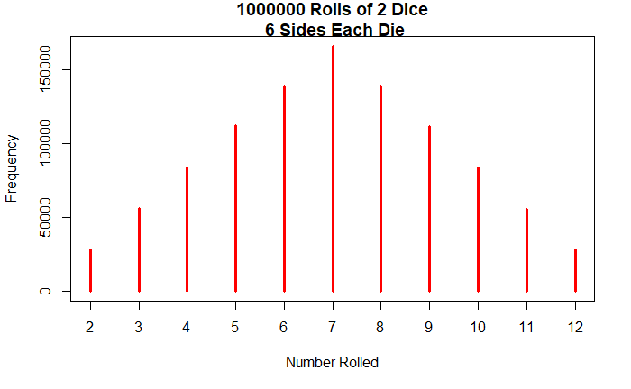

```r
options(scipen = 10)
plot(freq.rolls.tbl, xlab = 'Number Rolled', ylab = 'Frequency',
     type = 'h', col = 'red', lwd = 3,
     main = paste(rolls, 'Rolls of',  num.dice, 'Dice\n', sides, 'Sides Each Die'))
```

### Create a Frequency Table

```r
print(freq.rolls.tbl)
```

```
     2      3      4      5      6      7      8      9     10
 27854  55783  83185 111843 139080 165843 138811 111160  83171
    11     12
 55354  27916
```